# Can we predict the stock market using machine learning?

Duc Ngo, Rita Liu, Sivhuo Prak

## Introduction

The financial market is a strange place that is very hard to navigate around. We have seen Warren Buffett, Ray Dalio, Charlie Munger - the very very best who have had billions of dollars. Others, 95% of the population, lose the money instead.

So, how are the best of the best pick its stocks? It is from the fundamental, the technical side or the sentimental side? Within this paper, we hope to bring another perspective, using machine learning models to predict the profitability of the stock price.

### List of Variables

For the dataset, we includes financial information on companies in the S&P 500 stock index from 1999-2021. This information was scraped from Yahoo Finance in November of 2021, and collected in a csv format for data analysis. The information includes metrics like sales, earnings, cogs, stock price, and market sector as well as macroeconomic data such as GDP or Money Supply. The goal is to analyze and model this data to better improve projections for a company’s future profitability. The variables in the data set are described below:

| Variable | Meaning |
| --- | --- |
| YEAR | The financial year of the company |
| COMPANY | The company’s stock abbreviation symbol |
| MARKET.CAP | The total market capitalization of the company (Volume * Price) |
| EARNINGS | The earnings in dollars for the previous year for the given company |
| SALES | How much the company sold in dollars last year |
| CASH | How much cash the company has in dollars at the end of the previous year |
| Name | The full name of the company |
| Sector | The name of the sector that the company is a part of |
| PRICE | The price of the stock when it is bought |
| Sell | The price of the stock when it is sold |
| VOLUME | The total number of shares that the company has at that moment |
| COGS | The total amount the company paid as a cost directly related to the sale of products |
| INVESTMENT | The total asset or item acquired with the goal of generating income or appreciation |
| RECIEVABLE | The debts owed to a company by its customers for goods that have been delivered or used but not yet paid for |
| INVENTORY | How much raw materials used in production as well as the goods produced that are available for sale |
| DEBTS | How much money the company borrow from other parties |
| CPALTT01USM657N_PC1 | The percentage change in CPI (measure of inflation) |
| GDP | The monetary value of all finished goods and services made within a country |
| GDP_PC1 | The percentage change in GDP |
| T10Y2Y | Ten year treasury bonds minus two year treasury bonds |
| M1SL | The total currency and other liquid instruments in a country’s economy |
| M1SL_PC1 | The percentage change in money supply |
| PROFIT | How much the money made or lost on an investment |

## Data Preprocessing

For the data preprocessing, we combined our data sources and filled missing values for some fundamental factors by using the median of that value in the sector for a certain year. We also created sector dummies in this step. We then dropped some variables that are not in our interests and the splited the testing and trainning data.

| YEAR | T10Y2Y | VOLUME | MARKET CAP | EARNINGS | COGS | SALES | CASH | INVESTMENTS | RECEIVABLE | INVENTORY | DEBTS | Name | Sector | PROFIT | Sector_Communication Services | Sector_Consumer Discretionary | Sector_Consumer Staples | Sector_Energy | Sector_Financials | Sector_Health Care | Sector_Industrials | Sector_Information Technology | Sector_Materials | Sector_Real Estate | Sector_Utilities | CPALTT01USM657N_PC1 | GDP | GDP_PC1 | M1SL_PC1 | … |
| --- | --- | --- | --- | --- | --- | --- | --- | --- | --- | --- | --- | --- | --- | --- | --- | --- | --- | --- | --- | --- | --- | --- | --- | --- | --- | --- | --- | --- | --- | --- |
| 1999 | 0.2 | 6426000000 | 176614593750 | 1350072000 | 2917617000 | 8458777000 | 534652000 | 1156849000 | 1297867000 | 361986000 | 1900000 | Cisco Systems | Information Technology | 139.56789 | 0 | 0 | 0 | 0 | 0 | 0 | 0 | 1 | 0 | 0 | 0 | 65.9 | 9631.127 | 6.3 | 2 | … |
| 1999 | 0.2 | 136000000 | 745875000 | 26900000 | 813900000 | 1458600000 | 202900000 | 0 | 220900000 | 31200000 | 51400000 | Quest Diagnostics | Health Care | 63.53276 | 0 | 0 | 0 | 0 | 0 | 1 | 0 | 0 | 0 | 0 | 0 | 65.9 | 9631.127 | 6.3 | 2 | … |
| 1999 | 0.2 | 1603286905 | 32386397084 | 156200000 | 860700000 | 1331200000 | 198600000 | 0 | 795500000 | 0 | 374196000 | Invesco | Financials | 15.35842 | 0 | 0 | 0 | 0 | 1 | 0 | 0 | 0 | 0 | 0 | 0 | 65.9 | 9631.127 | 6.3 | 2 | … |
| 1999 | 0.2 | 91032448 | 1217558992 | 102000000 | 991300000 | 1407900000 | 95600000 | 0 | 230000000 | 128300000 | 157900000 | PerkinElmer | Health Care | 156.29907 | 0 | 0 | 0 | 0 | 0 | 1 | 0 | 0 | 0 | 0 | 0 | 65.9 | 9631.127 | 6.3 | 2 | … |
| 1999 | 0.2 | 73297297 | 848645267 | 56500000 | 162900000 | 522100000 | 61500000 | 0 | 288300000 | 0 | 374196000 | Arthur J. Gallagher & Co. | Financials | 11.09317 | 0 | 0 | 0 | 0 | 1 | 0 | 0 | 0 | 0 | 0 | 0 | 65.9 | 9631.127 | 6.3 | 2 | … |

## Data Visualization

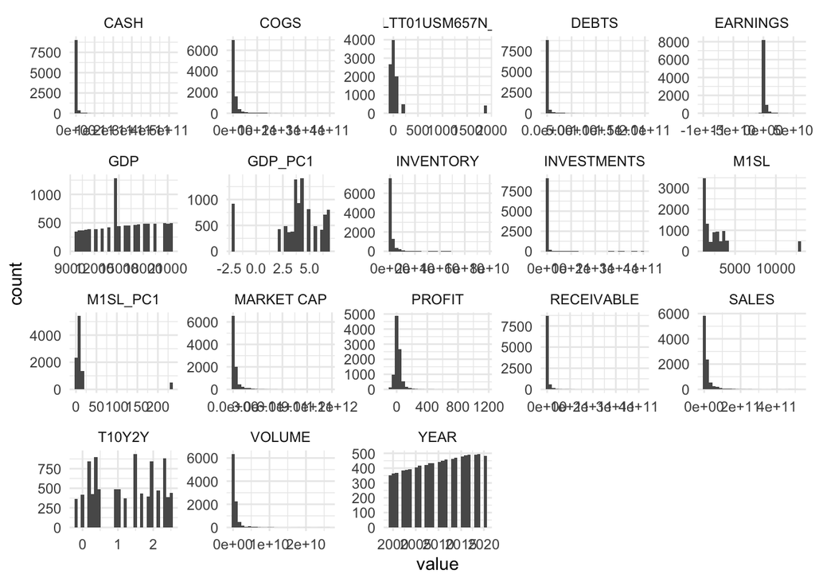

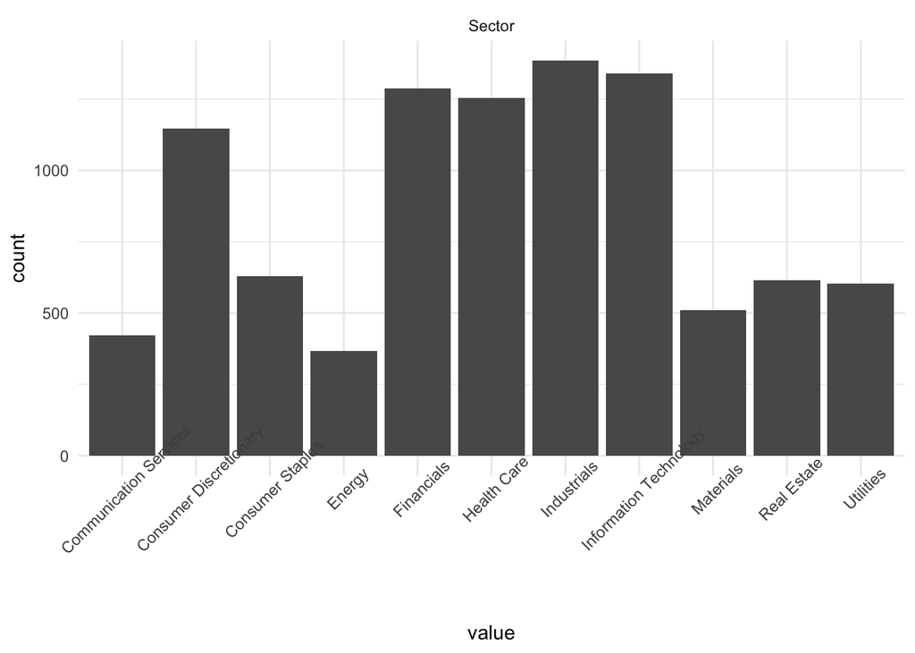

Then, we continued to explore the relationship between regressors and the outcome. By observation, we can’t see a strong correlation between fundemental factors, such as investments and debts, and stock return. It may indicate that linear model is not an ideal model in this case.

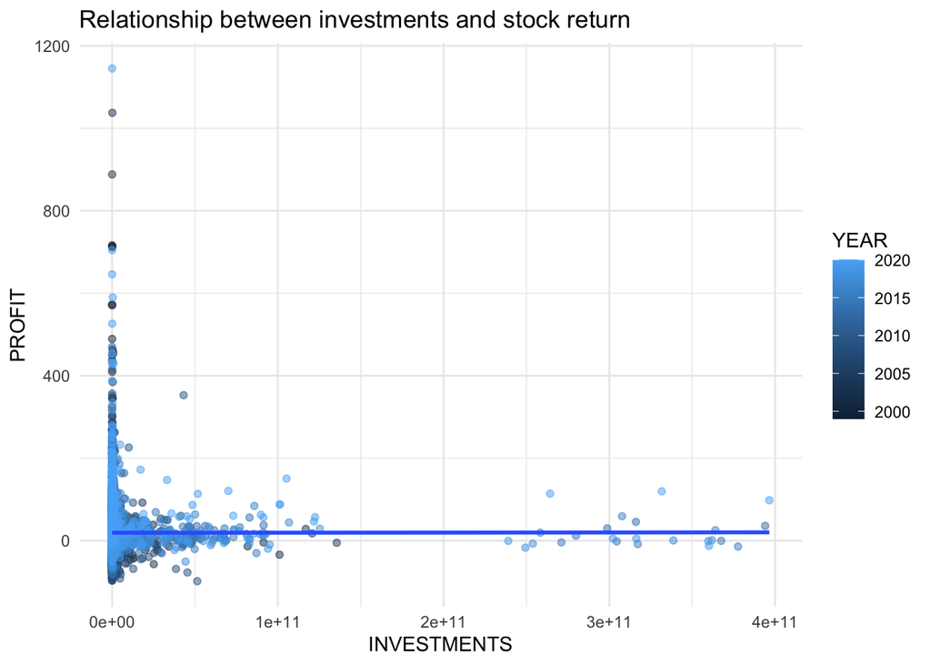

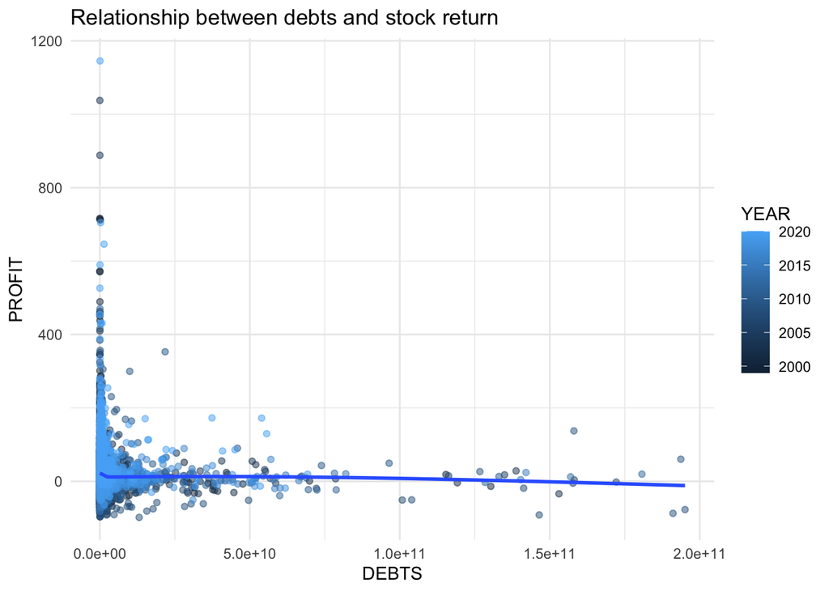

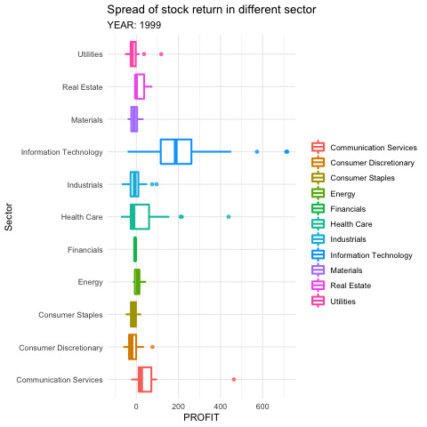

We further explored the relationship between the industry and the potential macroeconomic influencer using graphs below. Though the relationship doesn’t seem to be linear, we do see how macroeconomic condition affect each industry differently and will account for that in our model.

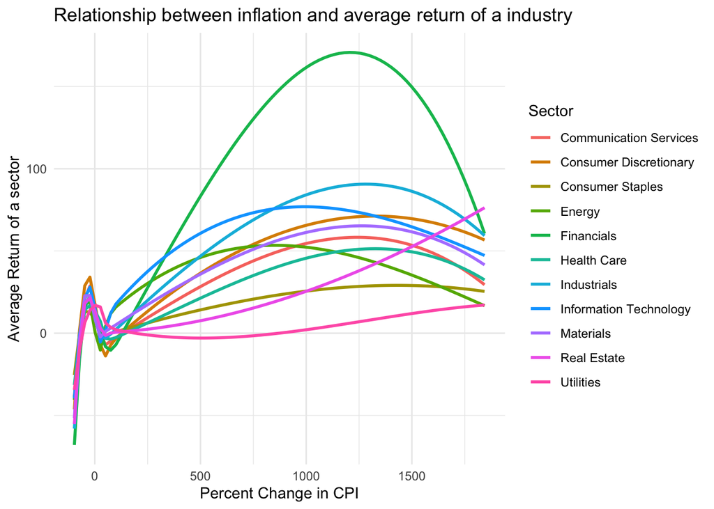

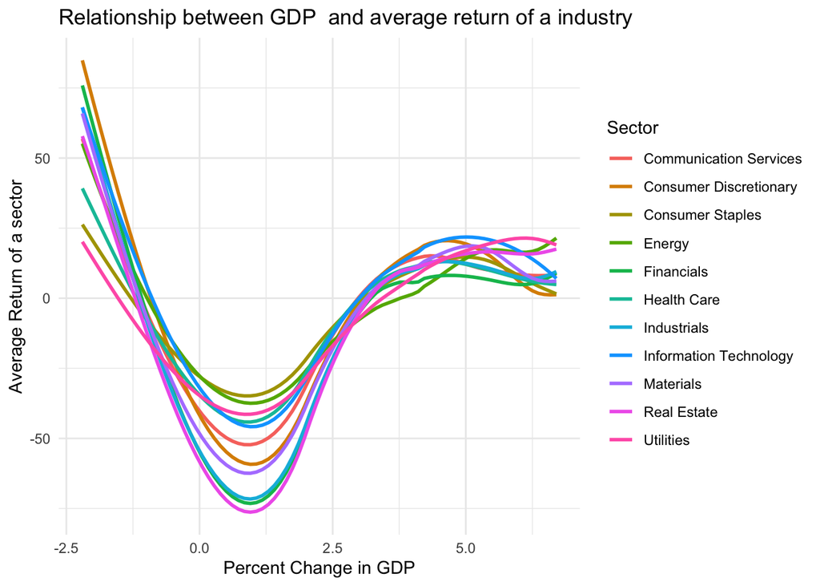

## Stock Return Prediction Using Lasso

### A Brief Overview on LASSO

LASSO(Least Absolute Shrinkage & Selection Operator) is a algorithm that penalizes less informative predictors on the basis of Least Square Regression. For OLS, our goal is to minimize the residual sum of squares[^1] whearas LASSO models try to minimize the RSS penalized by the number of coefficients[^2]. LASSO model will shrink the variables that are less important to zero.

### Results from Lasso

We used a Lasso model to predic the return.To account for the fact the macroeconomic condition affects each industry differently, we also included the interaction term between GDP and sector dummies. The table below shows the estimate of each predictor in the Lasso Model.We can see that indicators in macroeconomics are relatively important to predict the stock return. The change in inflation and GDP all remain significant after shrinking. The interaction terms between GDP and industries also showed importance, accounting for the fact that the macroeconomic condition affects each industry differently: GDP seems to affect the stock return in Communication Services, Energy, and Consumer Discretionary sectors less given there negative coefficient estimates. However, the Lasso model does not perform well. It only explains 20% of the varaince in stock return and it also has a prediction is typically off by 46.

Coefficient Estimates (LASSO)

| term | estimate | penalty |
| --- | --- | --- |
| M1SL | 52.2489802 | 0.0059948 |
| CPALTT01USM657N_PC1 | 22.8362276 | 0.0059948 |
| GDP_PC1 | 18.5139718 | 0.0059948 |
| (Intercept) | 17.4206737 | 0.0059948 |
| GDP_PC1_x_Sector_Utilities | 14.5169194 | 0.0059948 |
| GDP_PC1_x_`Sector_Consumer Staples` | 10.9623359 | 0.0059948 |
| GDP_PC1_x_`Sector_Health Care` | 10.0994574 | 0.0059948 |
| Sector_Information Technology | 9.1062940 | 0.0059948 |
| T10Y2Y | 8.3785234 | 0.0059948 |
| GDP_PC1_x_`Sector_Real Estate` | 7.9131832 | 0.0059948 |
| Sector_Communication Services | 7.4629557 | 0.0059948 |
| Sector_Health Care | 5.9942110 | 0.0059948 |
| Sector_Consumer Discretionary | 4.8412271 | 0.0059948 |
| GDP_PC1_x_`Sector_Information Technology` | 4.0219608 | 0.0059948 |
| Sector_Energy | 2.7587880 | 0.0059948 |
| COGS | 2.2012752 | 0.0059948 |
| GDP_PC1_x_Sector_Industrials | 2.0052201 | 0.0059948 |
| VOLUME | 0.9051955 | 0.0059948 |
| INVESTMENTS | 0.4845378 | 0.0059948 |
| CASH | 0.4031170 | 0.0059948 |
| EARNINGS | 0.3671604 | 0.0059948 |
| RECEIVABLE | 0.1688682 | 0.0059948 |
| INVENTORY | 0.1677270 | 0.0059948 |
| GDP_PC1_x_Sector_Financials | 0.0413482 | 0.0059948 |
| Sector_Materials | 0.0000000 | 0.0059948 |
| PE | -0.2304146 | 0.0059948 |
| DEBTS | -0.2444685 | 0.0059948 |
| Sector_Industrials | -0.4250661 | 0.0059948 |
| GDP_PC1_x_Sector_Materials | -1.0239217 | 0.0059948 |
| GDP_PC1_x_`Sector_Communication Services` | -1.4192763 | 0.0059948 |
| Sector_Financials | -1.5534082 | 0.0059948 |
| SALES | -3.2886701 | 0.0059948 |
| Sector_Real Estate | -3.3504621 | 0.0059948 |
| MARKET CAP | -3.8678288 | 0.0059948 |
| Sector_Consumer Staples | -5.4154183 | 0.0059948 |
| GDP_PC1_x_Sector_Energy | -5.8821361 | 0.0059948 |
| GDP_PC1_x_`Sector_Consumer Discretionary` | -8.6297519 | 0.0059948 |
| Sector_Utilities | -8.7405789 | 0.0059948 |
| M1SL_PC1 | -11.4973966 | 0.0059948 |
| GDP | -16.0930330 | 0.0059948 |

The graph below shows the most essential predictors for our model. We can see that macroeconomics indicators all ranked the top.

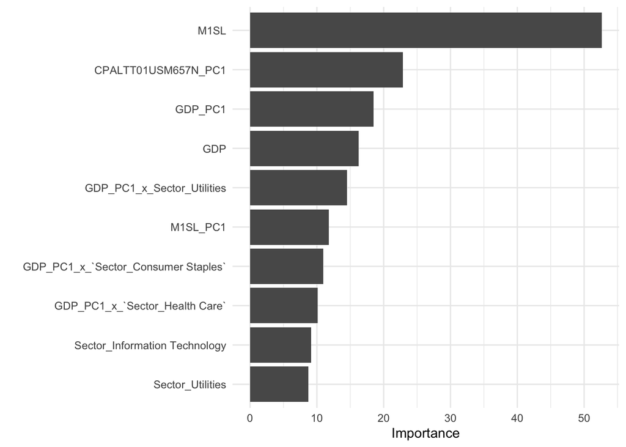

Here is the performance of the model on the testing data, the data we did not use to train our model. If the points and the blue line are perfectly aligned with the red line, it means a perfect prediction. We can see that our LASSO model does not perform well and tends to underestimate the stock with high returns, which are mostly from 2020 or earlier years.

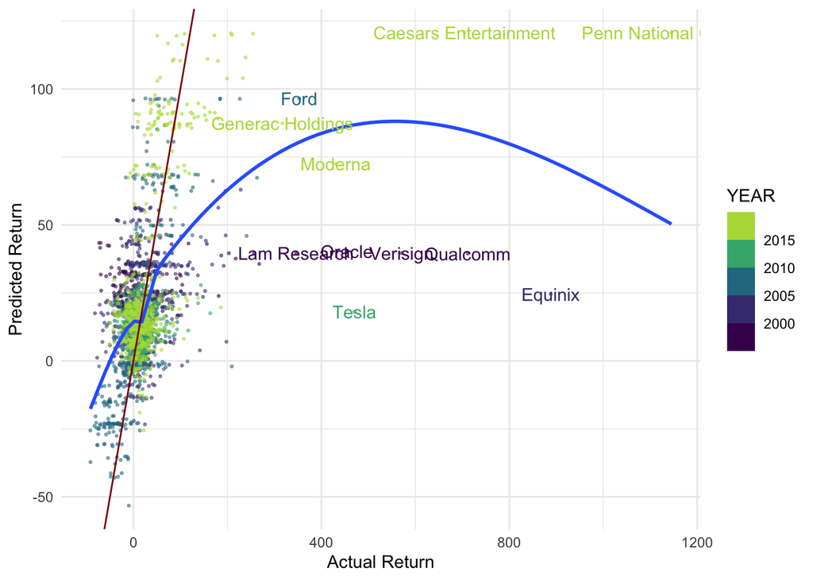

## Random Forest Model

A random forest is a supervised machine learning algorithm that is constructed from decision tree algorithms. It can be used to solve both regression and classification problems. It utilizes ensemble learning, which is a technique that combines many classifiers to provide solutions to complex problems. This algorithm consists of many decision trees and establishes the outcome based on the predictions of those trees. It takes the average of the output from various trees and make prediction.

We are going to train the random forest model by using `ranger` function with 200 trees and 6 variables randomly chosen at each split to predict our stock return.

### Random Forest Results

Below are the OOB prediction error (MSE), OOB root mean square error (RMSe), and R squared score from the random forest model we have trained above. The RMSE seems to be fairly high but significantly better than the LASSO model.

OOB MSE:

```
## [1] 1545.602
```

OOB RMSE:

```
## [1] 39.31415
```

R Squared:

```
## [1] 0.4084518
```

### Model Evaluation

#### Traning Data

We use K-fold cross validation technique to evaluate our model. Below are the root mean squared error (rmse) averaged over all the five folds on the training dataset.

| .metric | .estimator | mean | n | std_err | .config |
| --- | --- | --- | --- | --- | --- |
| rmse | standard | 39.31767 | 5 | 2.456402 | Preprocessor1_Model1 |

This is the graph showing the actual return vs. predicted return.

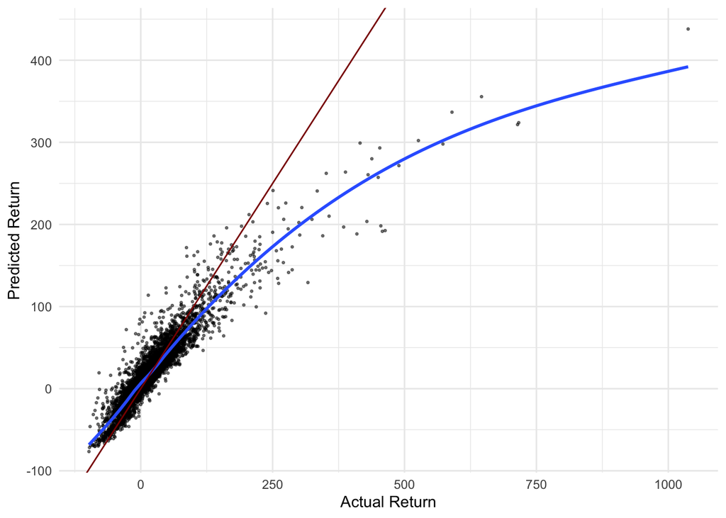

#### Testing Data

The table below shows the rmse on testing data. It is a bit higher but fairly similar to the error on training data so we could say that our model did not overfit.

| .metric | .estimator | mean | n | std_err | .config |
| --- | --- | --- | --- | --- | --- |
| rmse | standard | 47.41964 | 5 | 4.343728 | Preprocessor1_Model1 |

Below is the graph showing the actual return vs. predicted return on testing data.

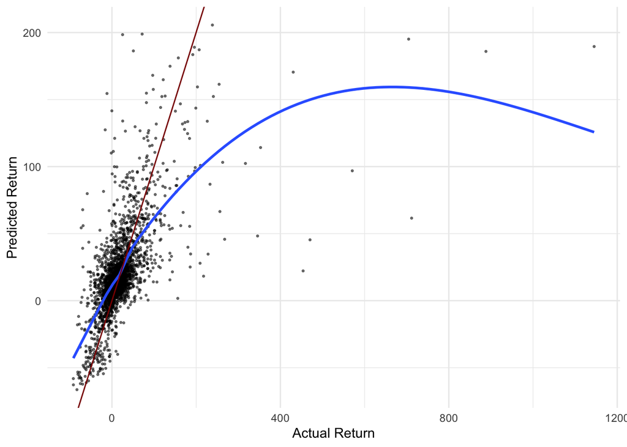

### Interpretable Machine Learning

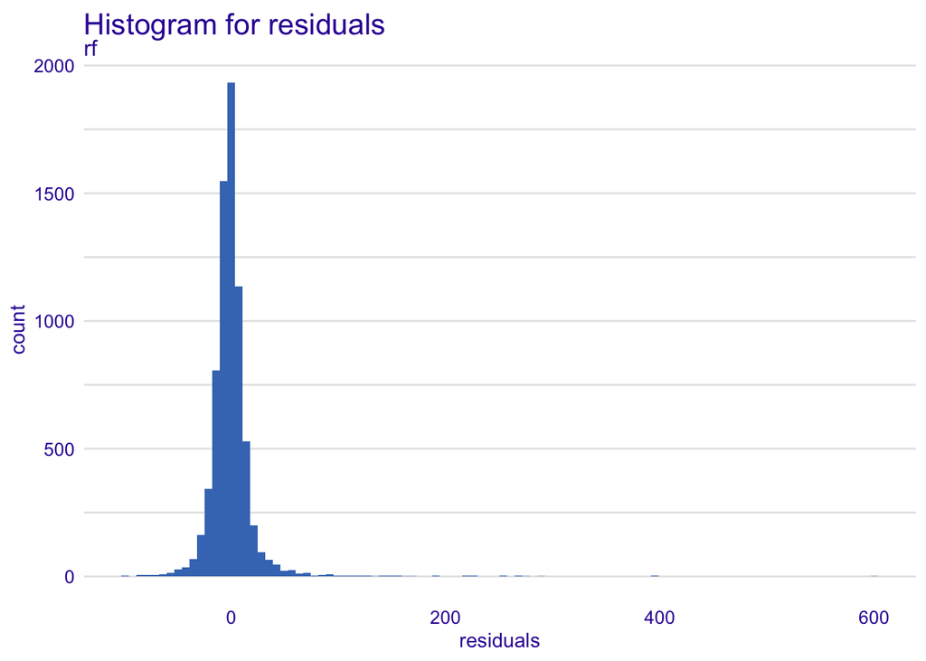

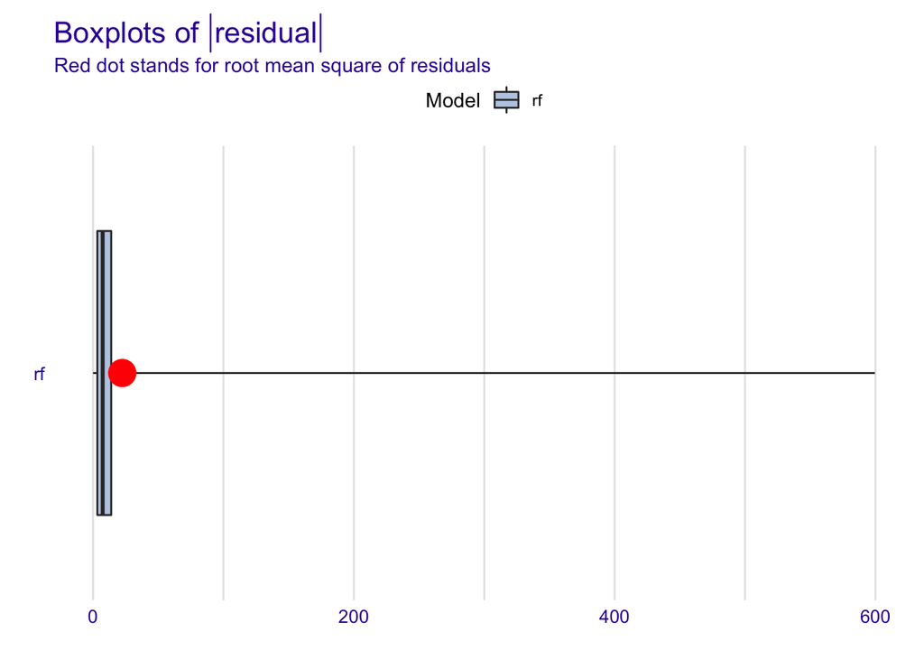

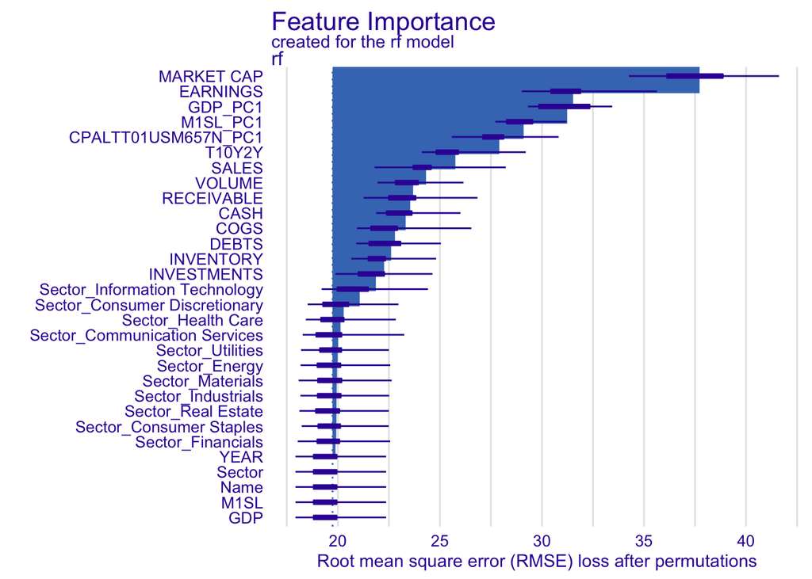

## Stacking model:

### Definition:

What is stacking? Model stacking is an ensembling method that takes the outputs of many models and combines them to generate a new model—referred to as an ensemble in this package—that generates predictions informed by each of its members.

### The process of stacking model:

Stacking model involves three separate steps:

1. Set up the ensemble:
- Specify a list of base learners (with a specific set of model parameters).
- Specify a meta learning algorithm.
2. Train the ensemble
- Train each of the base learners on the training set.
- Perform k-fold CV on each of the base learners and collect the cross-validated predictions from each (the same k-folds must be used for each base learner). These predicted values represent base learning models and the meta learning model, which can then be used to generate predictions on new data.
3. Predict on new data.
- To generate ensemble predictions, first generate predictions from the base learners.
- Feed those predictions into the meta learner to generate the ensemble prediction.

```
## # A tibble: 2 × 3
##   member        type             weight
##   <chr>         <chr>             <dbl>
## 1 ranger_cv_1_1 rand_forest       0.836
## 2 knn_tune_1_4  nearest_neighbor  0.253
```

| mean_rmse |
| --- |
| 39.70848 |

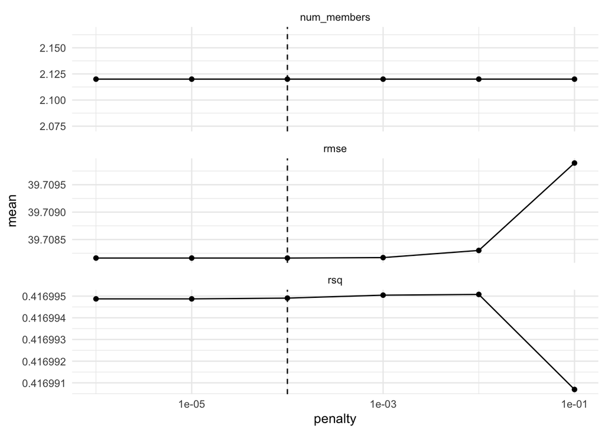

### The result of the stacking model:

| Name | .pred | PROFIT |
| --- | --- | --- |
| Penn National Gaming | 229.2917 | 1145.16767 |
| Devon Energy | 220.6574 | 238.58616 |
| Nvidia | 215.3806 | 203.04882 |
| Caesars Entertainment | 213.2249 | 704.61932 |
| Intuit | 211.0149 | 41.82483 |
| Ansys | 205.2033 | 81.81813 |
| PVH | 195.9183 | 207.11001 |
| Occidental Petroleum | 192.0519 | 157.63500 |
| Verisign | 191.4218 | 570.78464 |
| Dow | 190.1542 | 137.94378 |

After finishing our model, we then move on to compare the three models:

### Comparison of the three models

With the three models, we then move on to see which model performs the best:

#### Lasso model

| mean_rsq | mean_rmse |
| --- | --- |
| 0.2079744 | 45.48327 |

#### Random Forest Model

| mean_rmse | mean_rsq |
| --- | --- |
| 38.7362 | 0.4257162 |

#### Stacking Model

| mean_rmse | mean_rsq |
| --- | --- |
| 39.70848 | 0.4169942 |

## Stock Return Prediction for 2021

After picking our model, we then move on to use the model to predict the potential profit for 2021:

| Name | .pred | actual_ytd |
| --- | --- | --- |
| APA Corporation | 66.15775 | 80.30 |
| Under Armour (Class C) | 62.22877 | 39.77 |
| Norwegian Cruise Line Holdings | 62.12468 | -8.26 |
| DuPont | 62.07898 | 11.29 |
| News Corp (Class B) | 62.00012 | 22.08 |
| Ford | 61.51675 | 132.51 |
| Marathon Oil | 60.92993 | 137.04 |
| Carnival Corporation | 60.67833 | -4.22 |
| Under Armour (Class A) | 60.57563 | 39.77 |
| DXC Technology | 60.07332 | 20.76 |
| Raytheon Technologies | 58.76800 | 26.41 |
| Halliburton | 58.24086 | 26.34 |
| Schlumberger | 56.55640 | 41.50 |
| Devon Energy | 56.13831 | 178.43 |
| Baker Hughes | 55.92235 | 18.70 |
| ConocoPhillips | 55.85569 | 87.29 |
| Bristol Myers Squibb | 55.73066 | -6.16 |
| Hess Corporation | 55.56343 | 52.58 |
| United Airlines | 54.59626 | 8.70 |
| The Walt Disney Company | 54.55654 | -13.70 |

## Conclusion

The weakness of our model is that the average error of prediction is still very high so if one wants to predict the exact return, our model won’t be ideal. But the strength of our model is that for stocks with extremely high returns, even though the prediction might not be that precise, highly likely, our model will predict positive returns. That means, in real life, if we choose the top stocks to invest in based on our prediction, it is less likely we are going to lose money. Another strength of using a model to help with investment is that it excludes our subjective feelings.

To make the model better, we could do more research and add more regressors. For example, some financial indicators that are important for value investing are not reflected in our model due to the lack of data. Examples of those variables include Price to Sales, Price to Cash Flow, and Price to Book. Also, since we are concerned about the long-term return and all fundamental factors usually take longer to affect the firms, it’s probably helpful to do return in 2 years or 3 years or include lag of some variables in our model.

[^1]: $RSS_{OLS} = \sum_{i=1}^{n}(y_{i}-\hat{y_{i}})$
[^2]: Penalized RSS = $\sum_{i=1}^{n}(y_{i}-\hat{y_{i}}) + \lambda \sum_{j=1}^{p}|\hat{\beta_{j}}|$, where $\lambda$ is the penalty paramter and $\sum_{j=1}^{p}|\hat{\beta_{j}}|$ is the sum of non-intercept coefficients